# Identification of prioritized modules

Nguyen Huynh

17 December 2021

Abstract

Prioritized modules were tested for their preservation across different networks (SCZ vs HD). In the case of the GPC-Astrocyte transition network, SCZ and HD were tested against each other, and against the CTR network. This process produced significantly-correlated-to-condition modules, which were also prerserved across diseases. The script then utilized these prioritized modules to extract meaningful biological processes, as well as top-ranked genes.

```r
# Load necessary libraries
suppressPackageStartupMessages(library(WGCNA))
suppressPackageStartupMessages(library(fgsea))
suppressPackageStartupMessages(library(ggplot2))
suppressPackageStartupMessages(library(GeneOverlap))
suppressPackageStartupMessages(library(clusterProfiler))
suppressPackageStartupMessages(library(org.Hs.eg.db))
suppressPackageStartupMessages(library(stringr))
suppressPackageStartupMessages(library(SCENIC))
suppressPackageStartupMessages(library(DESeq2))
#
source("helper_functions.R")
options(stringsAsFactors = FALSE)
#
name2id <- read.table("./data/hs95_name2ID.txt", header = TRUE, stringsAsFactors = FALSE)
```

## PART 1: Preserved modules

Here, we showed the identification of preserved and significant modules for the astrocyte networks (HD vs SCZ). The process is similar for the GPC and transition networks.

#### Data import

Network preservation results from Script2

```r
netrep <- list(HD_vs_SCZ = readRDS("./results/NR_Astrocyte_HD_vs_SCZ.RDS"),
               SCZ_vs_HD = readRDS("./results/NR_Astrocyte_SCZ_vs_HD.RDS"))
```

Prioritized modules from Script3

```r
astro_hd_signif <- c("brown", "darkturquoise", "green", "greenyellow")
astro_scz_signif <- c("blue", "salmon", "tan", "yellow")
```

#### Pick prioritized modules by virtue of network preservation results

When a module is preserved when all six network characteristics significantly preserved (max p values < 0.01)

```r
max_pval <- lapply(netrep, function(x) apply(x$p.value, 1, max))
max_pval <- lapply(max_pval, function(x) x[which(x < 0.01)])

# Prune for signif_mods
max_pval <- lapply(max_pval, function(x) x[names(x) %in% unique(c(astro_hd_signif, astro_scz_signif))])
```

Here, we can see that module *blue* is the only one preserved in both the HD and SCZ astrocyte networks.

```r
max_pval
```

```
## $HD_vs_SCZ
##      blue    salmon    yellow
## 9.999e-05 9.999e-05 9.999e-05
##
## $SCZ_vs_HD
##      blue     brown
## 9.999e-05 9.999e-05
```

## PART 2: Enrichment of differentially expressed genes

The above preserved modules are analyzed with GSEA to identify modules where differentially expressed genes are enriched within. This is an example for the astrocyte networks.

#### Differentially expression analysis result

```r
# Results are from Script1
deg_res <- list(astro_hd = read.table("data/RUV_deSeq2_HD_Astro_vs_ESC_derived_CTR_Astro.txt", header = TRUE, stringsAsFactors = FALSE),
                astro_scz = read.table("data/RUV_deSeq2_SCZ_Astro_vs_iPSC_derived_CTR_Astro.txt", header = TRUE, stringsAsFactors = FALSE))
```

#### Extract gene IDs from modules of interest

```r
# Testing module blue from the astrocyte networks
# relabeled_modules is from Script2
relabeled_modules <- readRDS("results/relabeled_modules.RDS")
relabeled_modules <- lapply(relabeled_modules, function(x) {colorx <- labels2colors(x); names(colorx) <- names(x); return(colorx)})
# module blue
prior_set <- lapply(relabeled_modules[c("Astrocyte_HD", "Astrocyte_SCZ")], function(x) names(x)[x=="blue"])
names(prior_set) <- c("Astrocyte_HD_blue", "Astrocyte_SCZ_blue")
```

#### GSEA

```r
ranks <- lapply(deg_res, function(x) {fc <- sign(x$log2FoldChange);
                                      met <- fc*(-log10(x$pvalue));
                                      names(met) <- row.names(x);
                                      met <- met[order(met)];
                                      met <- met[!is.na(met)];
                                      return(met)})

fgsea_res <- lapply(ranks, function(r) fgsea(pathways = prior_set, stats = r, minSize = 15, maxSize = 5000, nperm = 10000))
```

Highlight modules whose NES goes in the same direction. In this case, module blue are downregulated in both HD and SCZ astrocytes.

```r
nes_view <- lapply(fgsea_res, function(x) x[, c("pathway", "NES")])
merge(nes_view[[1]], nes_view[[2]], by="pathway") %>% rename(pathway = pathway, NES_Astro_HD=NES.x, NES_Astro_SCZ = NES.y)
```

```
##               pathway NES_Astro_HD NES_Astro_SCZ
## 1:  Astrocyte_HD_blue    -2.306811     -2.837546
## 2: Astrocyte_SCZ_blue    -1.257326     -3.420396
```

Visualize

```r
datatoplot <- do.call(rbind, fgsea_res)
datatoplot$group <- rep(c("DEG HD", "DEG SCZ"), each = 2)
datatoplot$logP <- -log10(datatoplot$pval)
p <- ggplot(datatoplot, aes(x=group, y = pathway, size = logP, color = NES, group = group)) +
     geom_point() + theme_classic() +
     scale_color_gradient2(low = "navy", high = "red2", mid = "white", midpoint = 0) +
     labs(y="Module", x="") +
     theme(legend.position = "top", legend.title = element_text(size = 8),
           legend.text = element_text(size = 7), legend.margin = unit(0.5, "cm"),
           legend.box = "vertical",
           axis.text.x = element_text(angle = 30, hjust = 1))
```

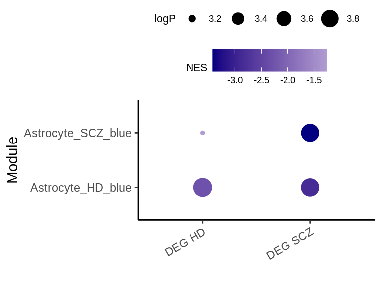

```r
p
```

## PART 3: Cluster characterization

After identification of modules that are significantly correlated to and explained by the covariate **condition**, these modules were pruned to retain only those who were significantly up- or downregulated in both HD and SCZ (same direction). The modules of interest are:  
**GPC**: GPC_SCZ_yellow, GPC_SCZ_purple, GPC_SCZ_lightcyan, GPC_HD_yellow, GPC_HD_salmon, GPC_HD_purple, GPC_HD_lightcyan  
**Astrocyte**: Astrocyte_SCZ_blue, Astrocyte_HD_blue

#### Investigate the degree of gene overlap for all modules of interest

```r
# A list of genes belonging to modules of interest
picked_set <- c("GPC_SCZ_yellow", "GPC_SCZ_purple", "GPC_SCZ_lightcyan", "GPC_HD_yellow", "GPC_HD_salmon", "GPC_HD_purple", "GPC_HD_lightcyan", "Astrocyte_SCZ_blue", "Astrocyte_HD_blue")
prior_set <- list()
for (module in picked_set) {
  x <- strsplit(module, "_")[[1]]
  network <- paste0(x[1], "_", x[2])
  module_of_interest <- x[3]
  # Get genes
  prior_set[[module]] <- names(relabeled_modules[[network]])[relabeled_modules[[network]]==module_of_interest]
}
```

```r
# Conduct pairwise fisher test for significant overlap of gene content
# 9369 is the number of genes retained after quality cut-off for this study
fisher_res <- compare(m = prior_set, gs = 9369)
fisher_res <- fisher_res[which(fisher_res$Fisher_pVal < 0.1),]
fisher_res$logP <- -log10(fisher_res$Fisher_pVal)
names(fisher_res) <- c("Source", "Target", "pVal", "logPval")
```

```r
fisher_res
```

```
##                Source             Target          pVal    logPval
## 3      GPC_SCZ_yellow      GPC_HD_yellow 2.734930e-130 129.563054
## 6      GPC_SCZ_yellow   GPC_HD_lightcyan  9.178898e-02   1.037209
## 11     GPC_SCZ_purple      GPC_HD_salmon  1.168080e-19  18.932527
## 12     GPC_SCZ_purple      GPC_HD_purple 3.468585e-216 215.459848
## 14     GPC_SCZ_purple Astrocyte_SCZ_blue  8.078329e-03   2.092678
## 15     GPC_SCZ_purple  Astrocyte_HD_blue  4.421300e-02   1.354450
## 19  GPC_SCZ_lightcyan   GPC_HD_lightcyan 3.008950e-106 105.521585
## 30      GPC_HD_salmon  Astrocyte_HD_blue  8.193566e-02   1.086527
## 32      GPC_HD_purple Astrocyte_SCZ_blue  5.196462e-02   1.284292
## 36 Astrocyte_SCZ_blue  Astrocyte_HD_blue 2.489200e-118 117.603940
```

#### Community detection

Community detection was carried out locally with Gephi. Result is imported here.

```r
# Getting the gene names
node_cluster <- read.csv("./data/gephi_module_community_detection.csv", stringsAsFactors = FALSE)
node_cluster$modularity_class <- node_cluster$modularity_class + 1
node_cluster_all_list <- list()
# Pour gene IDs into each cluster
for (i in 1:4) {
  node_modules <- node_cluster$Id[which(node_cluster$modularity_class == i)]
  # all genes in selected cluster
  node_modules.a.v <- Reduce(union, prior_set[node_modules])
  node_cluster_all_list[[i]] <- node_modules.a.v
}
names(node_cluster_all_list) <- paste0("C", 1:4)
```

#### Biological processes enriched per cluster

```r
egos <- lapply(node_cluster_all_list, function(x) enrichGO(gene = x, keyType = "ENSEMBL", OrgDb = org.Hs.eg.db, ont = "BP", pAdjustMethod = "BH", pvalueCutoff = 1e-4, qvalueCutoff = 0.01, readable = TRUE))
egoz <- lapply(egos, function(x) clusterProfiler::simplify(x, cutoff = 0.6))
```

```r
# Top
top_egos <- lapply(egoz, function(x) {z <- x@result; z$logP <- -log10(z$p.adjust);
                                      z <- z[order(z$logP),];
                                      z <- tail(z, n = 5);
                                      z$Description <- factor(z$Description, levels = z$Description)
                                      return(z)})
```

Visualize

```r
p_clusterProfiler <- list()
for (i in names(top_egos)) {
  p <- ggplot(top_egos[[i]], aes(y=logP, x = Description, fill = Count)) + geom_col() + coord_flip()
  p <- p + ggtitle(paste0(i, " - Pathway Enrichment")) + scale_fill_gradientn(colours = RColorBrewer::brewer.pal(9, "YlOrRd")) + ylab("-log10(padj)") + xlab("") + theme_bw()
  p <- p + scale_x_discrete(labels = function(x) str_wrap(x, width = 25)) + scale_y_continuous(expand = c(0,0), limits = c(0, max(top_egos[[i]]$logP) + 2))
  p <- p + theme(axis.text.y = element_text(colour = "black", size = 8), axis.text.x = element_text(size = 8), axis.title.x = element_text(size = 8), title = element_text(size = 8), legend.position = "bottom", legend.box = "vertical", legend.title = element_text(size = 7), legend.text = element_text(size = 7, angle = 30, hjust = 1))
  p_clusterProfiler[[i]] <- p
}
```

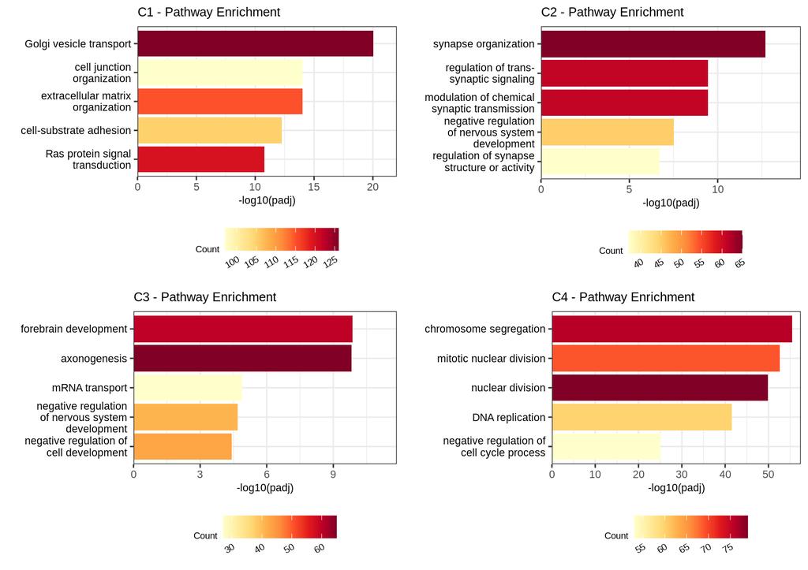

```r
cowplot::plot_grid(plotlist = p_clusterProfiler, ncol = 2)
```

#### Transcription factors whose direct targets are enriched per cluster

```r
source("Script4_SCENIC_Identifying_Regulons.R")
```

An output file from SCENIC where each target is assigned to corresponding TFs

```r
reg_res <- read.delim("./output/Step2_regulonTargetsInfo.tsv")
head(reg_res)
```

```
##   TF    gene nMotifs    bestMotif  NES highConfAnnot Genie3Weight
## 1 AR      AR       2 cisbp__M1935 3.22         FALSE           NA
## 2 AR  CTNND1       1 cisbp__M1935 3.22         FALSE  0.009641161
## 3 AR HEPACAM       1 cisbp__M1935 3.22         FALSE  0.008384180
## 4 AR    NFIC       1 cisbp__M1935 3.22         FALSE  0.006633006
## 5 AR  TTC3P1       2 cisbp__M1935 3.22         FALSE  0.005334721
## 6 AR  ZFYVE1       1 cisbp__M1935 3.22         FALSE  0.015817946
```

Compilation of genes by selected modules by gene names

```r
# Getting the gene names by mapping the ENSEMBL ID from our previous node_cluster_all_list
node_cluster_all_gn <- lapply(node_cluster_all_list, function(x) plyr::mapvalues(x, name2id$ensembl_gene_id, name2id$external_gene_name, warn_missing = FALSE))
```

Testing if there is a significant overlap between each TF’s targets and each cluster’s members

```r
tf_overlap <- data.frame(tf= character(), cluster = character(), pval = numeric(), intersection_size = numeric())
for (tf in unique(reg_res$TF)) {
  # Gene overlap test for each TF's target and cluster member
  target <- reg_res$gene[which(reg_res$TF == tf)]
  go <- lapply(node_cluster_all_gn, function(x) newGeneOverlap(x, target, genome.size = 9369))
  go <- lapply(go, testGeneOverlap)
  go.df <- lapply(go, function(x) data.frame(tf=tf, cluster="C", pval=x@pval, intersection_size=length(x@intersection)))
  go.df <- do.call(rbind, go.df)
  go.df$cluster <- row.names(go.df)
  tf_overlap <- rbind(tf_overlap, go.df)
}
# Adjust for multiple comparison
tf_overlap$BH <- p.adjust(tf_overlap$pval, method = "BH")
topTF <- tf_overlap %>% group_by(cluster) %>% top_n(-log10(BH), n = 15)
topTF$logP <- -log10(topTF$BH)
topTF.list <- topTF %>% group_by(cluster) %>% group_split(cluster)
topTF.list <- lapply(topTF.list, as.data.frame)
topTF.list <- lapply(topTF.list, function(x) {z <- x[order(x$logP), ]; z$tf <- factor(z$tf, levels = z$tf); return(z)})
names(topTF.list) <- paste0("C", 1:4)
```

Visualize

```r
p_TF <- list()
for (i in names(topTF.list)) {
  p <- ggplot(topTF.list[[i]], aes(y=logP, x = tf, fill = intersection_size)) + geom_col() + coord_flip()
  p <- p + ggtitle(paste0(i, " - TF Enrichment")) + scale_fill_gradientn(colours = RColorBrewer::brewer.pal(9, "RdPu")) + labs(y = "-log10(padj)", x = "", fill = "Count") + theme_bw()
  p <- p + scale_x_discrete(labels = function(x) str_wrap(x, width = 25)) + scale_y_continuous(expand = c(0,0), limits = c(0, max(topTF.list[[i]]$logP) + 2))
  p <- p + theme(axis.text.y = element_text(colour = "black", size = 8), axis.text.x = element_text(size = 8), axis.title.x = element_text(size = 8), title = element_text(size = 8), legend.position = "bottom", legend.box = "vertical", legend.title = element_text(size = 7), legend.text = element_text(size = 7, angle = 30, hjust = 1))
  p_TF[[i]] <- p
}
```

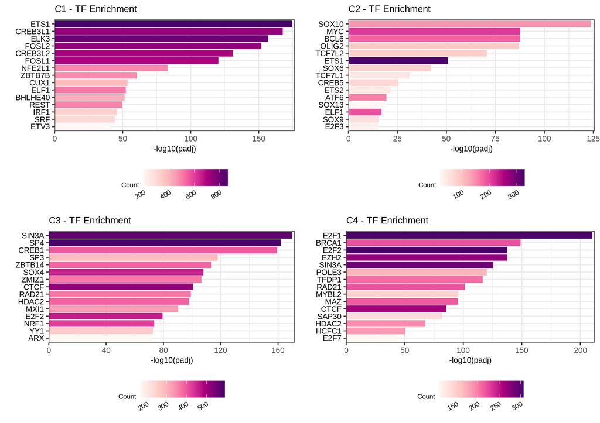

```r
cowplot::plot_grid(plotlist = p_TF, ncol = 2)
```

## PART 4: Construction of a multilayered network

#### Edges

Intersecting genes belonging to the aforementioned 9 prioritized modules were extracted. Their correlations within each respective network were imported (Script1 - biweight midcorrelation result) If a pair of genes exhibits more than 1 correlation (for more than 1 network), then the higest weight is picked.

```r
# Take the intersecting genes - This will be genes that are not unique for each cluster
all <- Reduce(union, prior_set)
uniq <- pullUnique(prior_set)
intersecting_genes <- all[! all %in% uniq]
```

Here, we demonstrate how to extract correlation weight from the appropriate network. For example: correlation of intersecting genes belonging to module **Astrocyte_SCZ_blue** from the **Astrocyte_SCZ** network. This step should be repeated for the other 8 modules in *picked_set*

```r
bicor.df <- data.frame(Var1=character(), Var2=character(), Freq=numeric(), Module = character())
m <- "Astrocyte_SCZ_blue"
# The biweight midcorrelation matrix
BIG <- readRDS("./results/Astrocyte_SCZ/bicor.RDS")
# The genes within module Astrocyte_SCZ_blue that are intersecting with other prioritized modules
gid <- prior_set[[m]][which(prior_set[[m]] %in% intersecting_genes)]
cat(paste0("Processing ", m, " with ", length(gid), " genes", "\n"))
```

```r
# Filter to only keep intersecting genes
bicor <- BIG$bicor[gid, gid]
pval <- BIG$p[gid,gid]
# wide to long format
bicor_long <- subset(as.data.frame(as.table(bicor)), match(Var1, colnames(bicor)) > match(Var2, colnames(bicor)))
pval_long  <- subset(as.data.frame(as.table(pval)), match(Var1, colnames(pval)) > match(Var2, colnames(pval)))
bicor_long <- cbind(bicor_long, pval_long$Freq)
# Remove correlation strengths that are not significant
bicor_long <- bicor_long[which(bicor_long$`pval_long$Freq` < 0.001),]
# Take the top 10% (90th percentile)
bicor_long <- bicor_long[order(bicor_long$`pval_long$Freq`),]
bicor_long <- bicor_long[which(abs(bicor_long$Freq) >= quantile(abs(bicor_long$Freq), probs = 0.9)),]
bicor_long$Module <- rep(m, nrow(bicor_long))
rm(BIG); gc()
```

A big data frame of all correlation weights of intersecting genes (compiled from all 9 prioritized modules) is now loaded. This is the edge table.

```r
bicor.df <- readRDS("./results/bicor_all9modules.RDS")
x <- strsplit(bicor.df$Module, "_")
bicor.df$Network <- paste(lapply(x, function(i) i[1]), lapply(x, function(x) x[2]), sep = "_")
```

#### Nodes

```r
# Make a igraph object, then calculate the eigenvector centrality
g <- igraph::graph_from_edgelist(as.matrix(bicor.df[,1:2]))
# Calculate eigenvector centrality with supplied weights
evc <- igraph::eigen_centrality(g, directed = FALSE, scale = TRUE, weights = bicor.df$Freq)
evc <- as.data.frame(evc$vector)

# Collective node strength
var1.strength <- bicor.df %>% group_by(Var1) %>% summarise(FreqAbs=sum(Freq))
var2.strength <- bicor.df %>% group_by(Var2) %>% summarise(FreqAbs=sum(Freq))
strength <- merge(var1.strength, var2.strength, by.x = "Var1", by.y = "Var2", all = TRUE)
strength[is.na(strength)] <- 0
strength$Strength <- apply(strength[,2:3], 1, sum)

# Node table
node <- merge(strength, evc, by.x = "Var1", by.y = "row.names", all = TRUE)[, c(1,4,5)]
colnames(node) <- c("Node", "Node_Strength", "Eigenvector_Centrality")
```

Assign cluster to each node

```r
bicor2.df <- bicor.df
colnames(bicor2.df)[1:2] <- c("Var", "Var")
bicor2.df <- rbind(bicor2.df[,c(1,3,5,6)], bicor2.df[,c(2,3,5,6)])
#
# For each node, if it appears in more than 1 cluster, report all clusters
# By mapping to module name, repeated nodes will be kept because module is unique to cluster
bicor2.df$Cluster <- paste0("C", plyr::mapvalues(bicor2.df$Module, node_cluster$Id, node_cluster$modularity_class))
# Sum all the weights per gene per cluster
bicor2.df <- bicor2.df %>% group_by(Var, Cluster) %>% summarize(Cluster_Node_Strength = sum(Freq))
# In case of repeated nodes, node will be assigned cluster with highest cumulative strength
bicor2.df <- bicor2.df %>% group_by(Var) %>% filter(Cluster_Node_Strength == max(Cluster_Node_Strength))
bicor2.df <- as.data.frame(bicor2.df)

node <- merge(node, bicor2.df, by.x = "Node", by.y = "Var")
node$Node <- as.character(node$Node)
node$geneName <- plyr::mapvalues(node$Node, name2id$ensembl_gene_id, name2id$external_gene_name, warn_missing = FALSE)
node <- node[order(node$Node_Strength, decreasing = TRUE), ]
```

```r
# Save to ./results for later retrieval
write.csv(node, "./results/PrioritizedGenes_Multilayered_node.csv", quote = FALSE, row.names = FALSE)
write.csv(bicor.df, "./results/PrioritizedGenes_Multilayered_edge.csv", quote = FALSE, row.names = FALSE)
```

#### Prioritization of clusters

Visualize

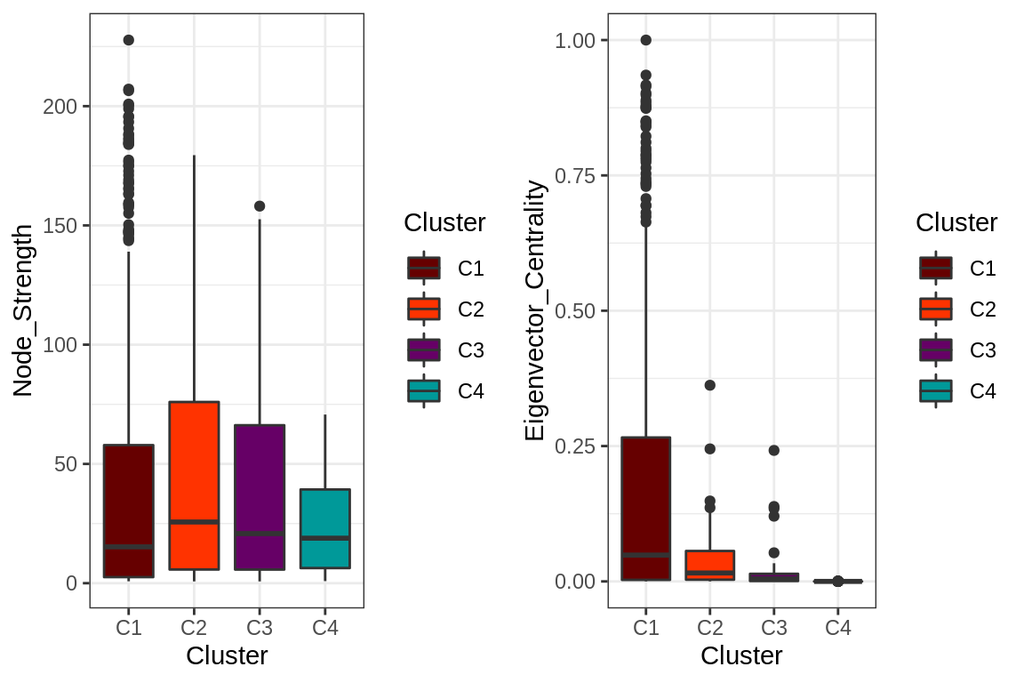

```r
my_color <- c("#660000", "#FF3300", "#660066", "#009999")
p1 <- ggplot(node, aes(x=Cluster, y = Node_Strength, fill = Cluster)) + geom_boxplot() + theme_bw() + scale_fill_manual(values = my_color)
p2 <- ggplot(node, aes(x=Cluster, y = Eigenvector_Centrality, fill = Cluster)) + geom_boxplot() + theme_bw() + scale_fill_manual(values = my_color)
cowplot::plot_grid(p1, p2, ncol =2)
```

## PART 5: Identification of top-ranked genes

Top-ranked genes are those within the 85th percentile, and exhibited either up- or down-regulated trends (log2FC) in both HD and SCZ.

```r
top_node <- read.csv("./data/PrioritizedGenes_Top_node.csv", header = TRUE, stringsAsFactors = FALSE)
```